# Calibrated Bin50 B-lineage RNA coverage

This report documents the approved primary definition: patient/UMI-calibrated q90 extended-panel score, at least two informative extended genes detected in the center-excluded 50 µm neighborhood, and at least five connected positive Bin50. Components of at least three bins are retained as a sensitivity result.

The endpoint is **B-lineage RNA coverage**, not B-cell identity, a B-cell niche, an aggregate, or a TLS call. Disease labels were not used to construct or calibrate the mask.

## Reproducible render command

The exact command is stored in `scripts/1054_render_b_lineage_coverage_report.sh`. It generates a `YYMMDDHHMMSS` timestamp, sets the two input directories as environment variables, executes this notebook with nbconvert, and writes the HTML to `results/` and the render log to `logs/`.

```python
from pathlib import Path
import json
import os
import platform
import sys

import matplotlib
import pandas as pd
from IPython.display import Image, Markdown, display

project_root = Path(os.environ['B_COVERAGE_PROJECT_ROOT']).resolve()
result_dir = Path(os.environ['B_COVERAGE_RESULT_DIR']).resolve()
rule_audit_dir = Path(os.environ['B_COVERAGE_RULE_AUDIT_DIR']).resolve()
assert result_dir.exists(), result_dir
assert rule_audit_dir.exists(), rule_audit_dir

chip_summary = pd.read_csv(result_dir / '04_PRIMARY_MASK_CHIP_SUMMARY.tsv', sep='\t')
spatial = pd.read_csv(result_dir / '02_SPATIAL_RULE_COMPARISON.tsv', sep='\t')
patient = pd.read_csv(result_dir / '03_PATIENT_COVERAGE_SUMMARY.tsv', sep='\t')
audit = pd.read_csv(result_dir / 'qc/05_FINAL_MASK_AUDIT.tsv', sep='\t')
genes = pd.read_csv(rule_audit_dir / '04_GENE_INFORMATIVENESS_AUDIT.tsv', sep='\t')
session = json.loads((result_dir / 'SESSION_INFO.json').read_text(encoding='utf-8'))
assert audit['passed'].all()
display(Markdown(f'**Final result directory:** `{result_dir.relative_to(project_root)}`'))
```

**Final result directory:** `results/reanalysis/B_LINEAGE_CALIBRATED_COVERAGE_MASK_GE5_20261010_215212`

## Frozen definitions and audit

```python
display(pd.DataFrame({'item': session.keys(), 'value': [str(value) for value in session.values()]}))
display(audit)
```

|  | item | value |
| --- | --- | --- |
| 0 | primary_definition | q90 patient/UMI-matched score, >=2 informative... |
| 1 | sensitivity_definitions | ['q90 patient/UMI-matched score, >=2 informati... |
| 2 | interpretation | B-lineage RNA coverage region; not a B-cell id... |
| 3 | disease_labels_used | False |
| 4 | stochastic_steps | False |

|  | audit_item | observed | expected | passed |
| --- | --- | --- | --- | --- |
| 0 | unique_bin_n | 29645 | 29645 | True |
| 1 | candidate_to_candidate_edge_n_positive | True | True | True |
| 2 | outside_candidate_neighbors_excluded_explicitly | True | True | True |
| 3 | primary_quantile | 0.9 | 0.9 | True |
| 4 | minimum_informative_gene_n | 2 | 2 | True |
| 5 | primary_minimum_component_n | 5 | 5 | True |
| 6 | sensitivity_minimum_component_n | 3 | 3 | True |
| 7 | disease_labels_unused | True | True | True |
| 8 | ge5_is_subset_of_ge3 | True | True | True |
| 9 | q90_is_superset_of_q95_bin_calls | True | True | True |

## Informative extended genes

```python
extended = genes[genes['panel'].eq('B__extended_only')].copy()
informative = extended[extended['informative_for_bin_rule']].sort_values('median_matched_score_delta', ascending=False)
display(Markdown(f'**Informative extended genes retained:** {len(informative)}'))
display(informative[['gene', 'evaluable_patient_n', 'positive_score_delta_patient_n', 'positive_chip_n', 'median_matched_score_delta', 'median_matched_detection_delta']])
```

**Informative extended genes retained:** 10

|  | gene | evaluable_patient_n | positive_score_delta_patient_n | positive_chip_n | median_matched_score_delta | median_matched_detection_delta |
| --- | --- | --- | --- | --- | --- | --- |
| 15 | RBM6 | 21 | 18 | 3 | 0.127390 | 0.029337 |
| 5 | ARHGAP24 | 21 | 18 | 3 | 0.122764 | 0.038320 |
| 18 | ZCCHC7 | 21 | 17 | 3 | 0.114549 | 0.042809 |
| 17 | USP34 | 21 | 19 | 3 | 0.114257 | 0.059064 |
| 11 | MGAT5 | 21 | 18 | 3 | 0.104324 | 0.084511 |
| 16 | SAMD12 | 21 | 17 | 3 | 0.093241 | 0.023291 |
| 10 | MAP4K4 | 21 | 17 | 3 | 0.084500 | 0.042430 |
| 7 | ITSN2 | 21 | 17 | 3 | 0.084013 | 0.036502 |
| 12 | NCOA3 | 21 | 18 | 3 | 0.067680 | 0.046149 |
| 14 | PRDM2 | 21 | 17 | 3 | 0.046101 | 0.042402 |

## Primary q90, component ≥5 result

```python
display(chip_summary)
totals = chip_summary.select_dtypes('number').sum()
summary_lines = [
    f"Candidate Bin50: {int(totals['candidate_bin_n']):,}",
    f"q90 bin-supported before connectivity: {int(totals['calibrated_bin_support_n']):,}",
    f"Primary region-supported (component >=5): {int(totals['primary_region_support_n']):,}",
    f"Extended gain beyond the core-only comparator: {int(totals['extended_gain_n']):,}",
    f"Primary bins with core corroboration: {int(totals['core_corroborated_n']):,}",
]
display(Markdown('\n'.join(f'- {line}' for line in summary_lines)))
```

|  | chip | candidate_bin_n | calibrated_bin_support_n | primary_region_support_n | core_only_support_n | extended_gain_n | core_corroborated_n | calibrated_bin_support_fraction | primary_region_support_fraction | core_only_support_fraction | extended_gain_fraction | core_corroborated_fraction |
| --- | --- | --- | --- | --- | --- | --- | --- | --- | --- | --- | --- | --- |
| 0 | J2 | 11893 | 1760 | 545 | 124 | 472 | 209 | 0.147986 | 0.045825 | 0.010426 | 0.039687 | 0.017573 |
| 1 | L3 | 14839 | 2509 | 1386 | 1247 | 954 | 884 | 0.169081 | 0.093403 | 0.084035 | 0.064290 | 0.059573 |
| 2 | Y40102K8 | 2913 | 1107 | 738 | 975 | 88 | 718 | 0.380021 | 0.253347 | 0.334706 | 0.030209 | 0.246481 |

- Candidate Bin50: 29,645

- q90 bin-supported before connectivity: 5,376

- Primary region-supported (component >=5): 2,669

- Extended gain beyond the core-only comparator: 1,514

- Primary bins with core corroboration: 1,811

## Component ≥3 sensitivity and q95 sensitivity

```python
comparison = (spatial.groupby('background_quantile', as_index=False)[['bin_n', 'called_n', 'region_supported_ge3_n', 'region_supported_ge5_n']].sum())
display(comparison)
q90 = comparison[comparison['background_quantile'].eq(0.90)].iloc[0]
display(Markdown(f"At q90, raising the connectivity criterion from ≥3 to ≥5 changes the retained mask from **{int(q90['region_supported_ge3_n']):,}** to **{int(q90['region_supported_ge5_n']):,}** Bin50."))
```

|  | background_quantile | bin_n | called_n | region_supported_ge3_n | region_supported_ge5_n |
| --- | --- | --- | --- | --- | --- |
| 0 | 0.90 | 29645 | 5376 | 3429 | 2669 |
| 1 | 0.95 | 29645 | 3575 | 2135 | 1711 |

At q90, raising the connectivity criterion from ≥3 to ≥5 changes the retained mask from **3,429** to **2,669** Bin50.

## Patient-level coverage

```python
patient_q90 = patient[patient['background_quantile'].eq(0.90)].sort_values(['chip', 'patient'])
display(patient_q90[['chip', 'patient', 'candidate_bin_n', 'called_fraction', 'region_supported_ge3_fraction', 'region_supported_ge5_fraction']])
```

|  | chip | patient | candidate_bin_n | called_fraction | region_supported_ge3_fraction | region_supported_ge5_fraction |
| --- | --- | --- | --- | --- | --- | --- |
| 0 | J2 | HC/NL-55 | 1754 | 0.190992 | 0.103763 | 0.068415 |
| 1 | J2 | HC/NL-63 | 1556 | 0.136247 | 0.075835 | 0.036632 |
| 2 | J2 | IPF/FO23-1-03100 | 2317 | 0.119983 | 0.063444 | 0.025032 |
| 3 | J2 | IPF/FO23-1-09473 | 225 | 0.200000 | 0.057778 | 0.000000 |
| 4 | J2 | SSC/23-105334B1 | 3343 | 0.156446 | 0.081364 | 0.065510 |
| 5 | J2 | SSC/FO20-I-08293B1 | 1167 | 0.137104 | 0.060840 | 0.043702 |
| 6 | J2 | SSC/FO21-1-01756B1 | 1531 | 0.135206 | 0.067929 | 0.026127 |
| 7 | L3 | HC/NL-66 | 1196 | 0.127926 | 0.061873 | 0.031773 |
| 8 | L3 | HC/NL-72 | 3013 | 0.176236 | 0.122137 | 0.094258 |
| 9 | L3 | IPF/FO23-1-06168 | 1660 | 0.171687 | 0.109639 | 0.093976 |
| 10 | L3 | IPF/FO23-1-06170 | 1968 | 0.114837 | 0.059451 | 0.046240 |
| 11 | L3 | SSC/05957/17B | 828 | 0.097826 | 0.025362 | 0.020531 |
| 12 | L3 | SSC/07998/15A | 2295 | 0.149891 | 0.097603 | 0.069717 |
| 13 | L3 | SSC/15491/14 | 3879 | 0.229183 | 0.183552 | 0.164991 |
| 14 | Y40102K8 | HC/NL-50 | 132 | 0.356061 | 0.143939 | 0.037879 |
| 15 | Y40102K8 | HC/NL-53 | 593 | 0.172007 | 0.080944 | 0.057336 |
| 16 | Y40102K8 | IPF/FO22-1-09404 | 829 | 0.915561 | 0.849216 | 0.816647 |
| 17 | Y40102K8 | IPF/FO23-1-06474 | 247 | 0.117409 | 0.024291 | 0.024291 |
| 18 | Y40102K8 | SSC/15275/13 | 320 | 0.125000 | 0.046875 | 0.000000 |
| 19 | Y40102K8 | SSC/24-1-18170A2 | 756 | 0.166667 | 0.042328 | 0.021164 |
| 20 | Y40102K8 | SSC/3342/13 | 36 | 0.111111 | 0.000000 | 0.000000 |

## Spatial review

J2

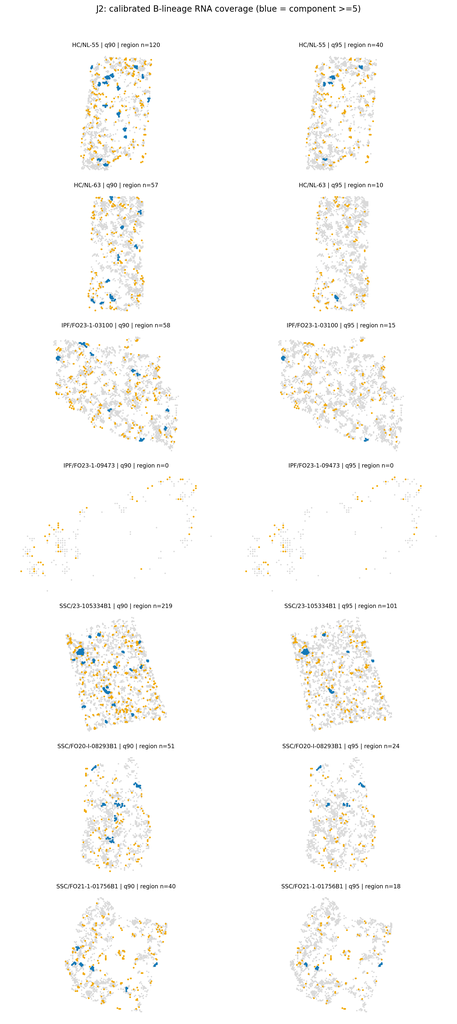

L3

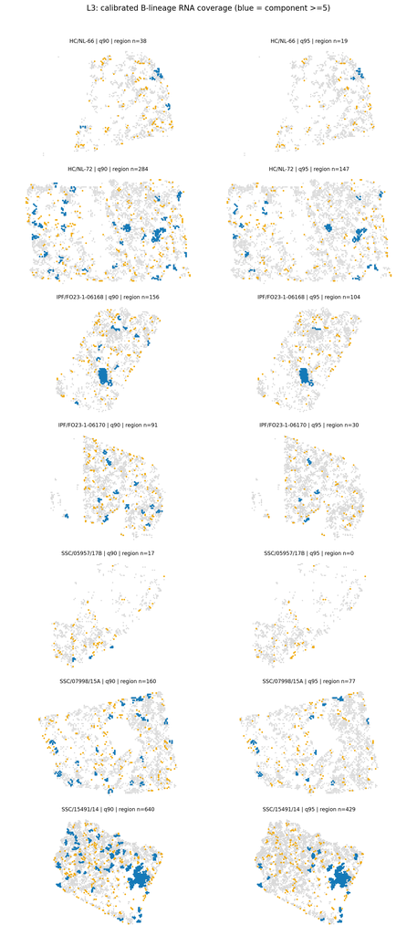

Y40102K8

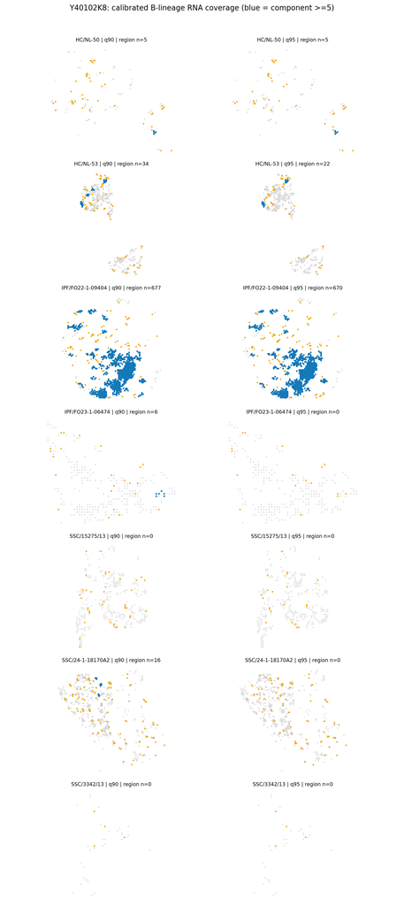

```python
for chip in ['J2', 'L3', 'Y40102K8']:
    image_path = result_dir / 'figures' / f'02_{chip}_Q90_Q95_SPATIAL_OVERVIEW_EN.png'
    display(Markdown(f'### {chip}'))
    display(Image(filename=str(image_path), width=1000))
```

## Interpretation boundary

The extended panel is used to increase detectable B-lineage RNA coverage in low-UMI spatial data. The UMI-matched q90 requirement limits calls driven by depth alone, the multi-gene requirement limits single broad-gene calls, and the five-bin connectivity criterion defines a spatial region rather than an isolated signal. Core genes are retained as corroboration and do not veto extended support. The result must not be interpreted as a pure B-cell label, cell count, aggregate, niche, or TLS annotation.

## Session information

```python
session_info = {
    'python': sys.version.replace('\n', ' '),
    'platform': platform.platform(),
    'pandas': pd.__version__,
    'matplotlib': matplotlib.__version__,
}
display(pd.DataFrame({'component': session_info.keys(), 'version': session_info.values()}))
```

|  | component | version |
| --- | --- | --- |
| 0 | python | 3.10.20 (main, Mar 11 2026, 17:46:40) [GCC 14.... |
| 1 | platform | Linux-6.6.87.2-microsoft-standard-WSL2-x86_64-... |
| 2 | pandas | 2.3.3 |
| 3 | matplotlib | 3.10.9 |